# Hands on 1

## 121140092

### 1. Membuat gelombang sinus dan Cosinus

```python
import numpy as np
import matplotlib.pyplot as plt

# Buat array t yang berkisar dari 0 hingga 2 dengan langkah sebesar 0.0001
t = np.arange(0, 2, 0.0001)

# Buat sinyal-sinyal menggunakan array waktu
y1 = 2 * np.sin(2 * np.pi * 3 * t + 0)
y2 = 1 * np.cos(2 * np.pi * 4 * t + np.pi/4)
y3 = -1 * np.sin(2 * np.pi * 5 * t + np.pi/2)
y4 = 0.5 * np.cos(2 * np.pi * 6 * t + np.pi)
```

### 2. Perbandingan subplot

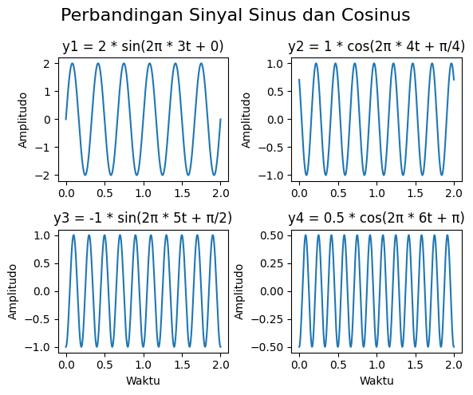

```python
# Membuat plot dengan 4 subplot dalam grid 2x2
fig, axs = plt.subplots(2, 2, figsize=(6, 5))
fig.suptitle('Perbandingan Sinyal Sinus dan Cosinus', fontsize=16)

# Plot untuk y1
axs[0, 0].plot(t, y1)
axs[0, 0].set_title('y1 = 2 * sin(2π * 3t + 0)')
axs[0, 0].set_ylabel('Amplitudo')

# Plot untuk y2
axs[0, 1].plot(t, y2)
axs[0, 1].set_title('y2 = 1 * cos(2π * 4t + π/4)')
axs[0, 1].set_ylabel('Amplitudo')

# Plot untuk y3
axs[1, 0].plot(t, y3)
axs[1, 0].set_title('y3 = -1 * sin(2π * 5t + π/2)')
axs[1, 0].set_xlabel('Waktu')
axs[1, 0].set_ylabel('Amplitudo')

# Plot untuk y4
axs[1, 1].plot(t, y4)
axs[1, 1].set_title('y4 = 0.5 * cos(2π * 6t + π)')
axs[1, 1].set_xlabel('Waktu')
axs[1, 1].set_ylabel('Amplitudo')

# Mengatur layout agar tidak tumpang tindih
plt.tight_layout()
plt.show()
```

### 3. Pertanyaan Analisis

#### A. Berapa amplitudo dan frekuensi masing-masing sinyal?

##### Sinyal y1

$ y1 = 2 * sin(2π * 3t + 0) $

Amplitudo: 2

Frekuensi: 3 Hz

##### Sinyal y2

$ y2 = 1 * cos(2π * 4t + π/4) $

Amplitudo: 1

Frekuensi: 4 Hz

##### Sinyal y3

$ y3 = -1 * sin(2π * 5t + π/2) $

Amplitudo: 1 (tanda negatif hanya membalik fase)

Frekuensi: 5 Hz

##### Sinyal y4

$ y4 = 0.5 * cos(2π * 6t + π) $

Amplitudo: 0.5

Frekuensi: 6 Hz

#### B. Bagaimana pergeseran fase mempengaruhi posisi gelombang?

[figure not shown]

```python
plt.figure(figsize=(12, 4))
plt.plot(t, y1, label='Fase 0')
plt.plot(t, y2, label='Fase π/8')
plt.plot(t, y3, label='Fase π/4')
plt.plot(t, y4, label='Fase π')
plt.title('Pengaruh Pergeseran Fase pada Sinyal Sinus dalam 1 plot')
plt.xlabel('Waktu')
plt.ylabel('Amplitudo')
plt.legend()
plt.grid(True)
plt.show()
```

[figure not shown]

```python
# Membuat figure dengan 4 subplot
plt.figure(figsize=(25, 15))
plt.title('Pengaruh Pergeseran Fase pada Sinyal Sinus dalam masing masing plot')
# Plot untuk Fase 0
plt.subplot(2, 2, 1)
plt.plot(t, y1)
plt.title('Fase 0')
plt.xlabel('Waktu')
plt.ylabel('Amplitudo')
plt.grid(True)

# Plot untuk Fase π/8
plt.subplot(2, 2, 2)
plt.plot(t, y2)
plt.title('Fase π/8')
plt.xlabel('Waktu')
plt.ylabel('Amplitudo')
plt.grid(True)

# Plot untuk Fase π/4
plt.subplot(2, 2, 3)
plt.plot(t, y3)
plt.title('Fase π/4')
plt.xlabel('Waktu')
plt.ylabel('Amplitudo')
plt.grid(True)

# Plot untuk Fase π
plt.subplot(2, 2, 4)
plt.plot(t, y4)
plt.title('Fase π')
plt.xlabel('Waktu')
plt.ylabel('Amplitudo')
plt.grid(True)

# Menampilkan plot
plt.tight_layout()
plt.show()
```

#### C. Bandingkan sinyal-sinyal dengan amplitudo yang berbeda dan diskusikan bagaimana amplitudo mempengaruhi tampilan gelombang.

[figure not shown]

```python
# Sinyal dengan amplitudo berbeda
y1 = 0.5 * np.sin(2 * np.pi * 2 * t)
y2 = 1.0 * np.sin(2 * np.pi * 2 * t)
y3 = 1.75 * np.sin(2 * np.pi * 2 * t)
y4 = 2.5 * np.sin(2 * np.pi * 2 * t)

plt.figure(figsize=(12, 4))
plt.plot(t, y1, label='Amplitudo 0.5')
plt.plot(t, y2, label='Amplitudo 1.0')
plt.plot(t, y3, label='Amplitudo 1.5')
plt.plot(t, y4, label='Amplitudo 2.0')
plt.title('Pengaruh Amplitudo pada Sinyal Sinus')
plt.xlabel('Waktu')
plt.ylabel('Amplitudo')
plt.legend()
plt.grid(True)
plt.show()
```

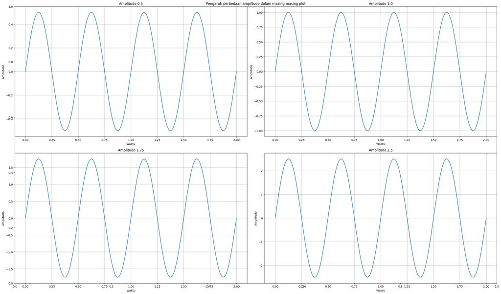

```python
plt.figure(figsize=(25, 15))
plt.title('Pengaruh perbedaan ampiltudo dalam masing masing plot')
# Plot untuk Amplitudo 0.5
plt.subplot(2, 2, 1)
plt.plot(t, y1)
plt.title('Amplitudo 0.5')
plt.xlabel('Waktu')
plt.ylabel('Amplitudo')
plt.grid(True)

# Plot untuk Amplitudo 1.0
plt.subplot(2, 2, 2)
plt.plot(t, y2)
plt.title('Amplitudo 1.0')
plt.xlabel('Waktu')
plt.ylabel('Amplitudo')
plt.grid(True)

# Plot untuk Amplitudo 1.75
plt.subplot(2, 2, 3)
plt.plot(t, y3)
plt.title('Amplitudo 1.75')
plt.xlabel('Waktu')
plt.ylabel('Amplitudo')
plt.grid(True)

# Plot untuk Amplitudo 2.5
plt.subplot(2, 2, 4)
plt.plot(t, y4)
plt.title('Amplitudo 2.5')
plt.xlabel('Waktu')
plt.ylabel('Amplitudo')
plt.grid(True)

# Menampilkan plot
plt.tight_layout()
plt.show()
```

Analisis dengan amplitudo yang diubah:

Amplitudo mempengaruhi tinggi gelombang. Semakin besar amplitudo, semakin tinggi puncak dan semakin rendah lembah gelombang. Amplitudo tidak mempengaruhi frekuensi atau periode gelombang.

#### D. Bandingkan sinyal-sinyal dengan pergeseran fase yang berbeda dan diskusikan bagaimana pergeseran fase mempengaruhi tampilan gelombang.

Pergeseran fase mempengaruhi posisi awal gelombang pada sumbu waktu:

Fase 0 (y1): Dimulai dari titik 0 dan bergerak naik.

[figure not shown]

```python
plt.figure(figsize=(12, 4))
plt.plot(t, y1, label='Fase 0')
plt.plot(t, y2, label='Fase π/8')
plt.plot(t, y3, label='Fase π/4')
plt.plot(t, y4, label='Fase π/2')
plt.title('Perbandingan Sinyal dengan Pergeseran Fase Berbeda')
plt.xlabel('Waktu')
plt.ylabel('Amplitudo')
plt.legend()
plt.grid(True)
plt.show()
```

### 4. Tugas Lanjutan

#### - buat sinyal baru (y5)

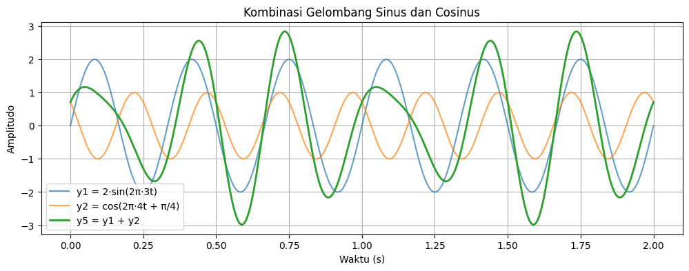

```python
y1 = 2 * np.sin(2 * np.pi * 3 * t)
y2 = 1 * np.cos(2 * np.pi * 4 * t + np.pi/4)
y5 = y1 + y2

# Membuat plot
plt.figure(figsize=(12, 4))

plt.plot(t, y1, label='y1 = 2·sin(2π·3t)', alpha=0.7)
plt.plot(t, y2, label='y2 = cos(2π·4t + π/4)', alpha=0.7)
plt.plot(t, y5, label='y5 = y1 + y2', linewidth=2)

plt.title('Kombinasi Gelombang Sinus dan Cosinus')
plt.xlabel('Waktu (s)')
plt.ylabel('Amplitudo')
plt.legend()
plt.grid(True)

plt.show()
```

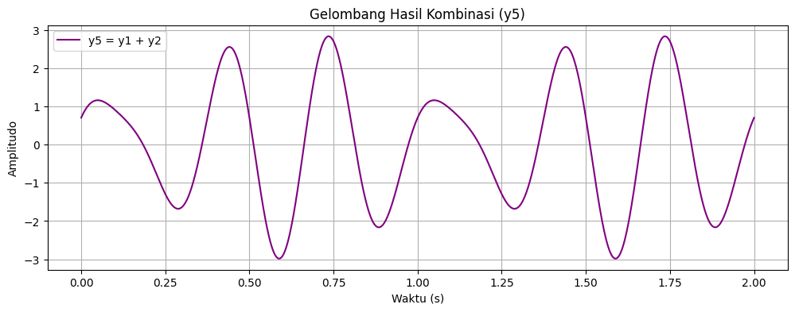

```python
plt.figure(figsize=(12, 4))
plt.plot(t, y5, label='y5 = y1 + y2', color='purple')
plt.title('Gelombang Hasil Kombinasi (y5)')
plt.xlabel('Waktu (s)')
plt.ylabel('Amplitudo')
plt.legend()
plt.grid(True)

plt.show()
```

#### - bagaimana kombinasi dua gelombang sinus/cosinus mempengaruhi bentuk gelombang yang dihasilkan.

Hasil kombinasi ini akan menghasilkan gelombang yang memiliki ;

- Bentuk yang tidak beraturan: Karena frekuensi yang berbeda, yaitu y1 (3 Hz) memiliki periode yang lebih panjang dibandingkan y2 (4 Hz). gelombang akan memiliki pola yang berulang setelah periode tertentu (ketika kedua komponen kembali sefase). y5 akan memiliki bentuk yang lebih kompleks dibandingkan gelombang sinus atau cosinus sederhana.
- Amplitudo yang bervariasi: Pada beberapa titik, kedua gelombang akan saling menguatkan (interferensi konstruktif), sementara pada titik lain akan saling melemahkan (interferensi destruktif). sinyal y5 akan menunjukkan variasi amplitudo yang lebih besar dari komponen-komponennya.
- Karena perbedaan frekuensi yang kecil (4 Hz - 3 Hz = 1 Hz), akan terlihat pola "beating" atau modulasi amplitudo dengan frekuensi yang lebih rendah yang merupakan hasil dari perbedaan frekuensi antara y1 dan y2..
- Asimetri: Kombinasi sinus dan cosinus akan menghasilkan gelombang yang tidak simetris terhadap sumbu waktu.

### 5. downsampling dari 150Hz ke 100Hz, 50Hz, 25Hz, 10Hz, hingga 5Hz

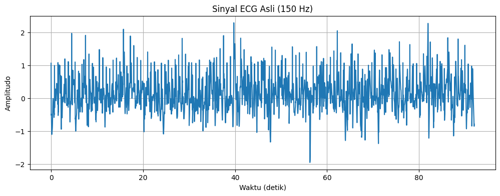

[figure not shown]

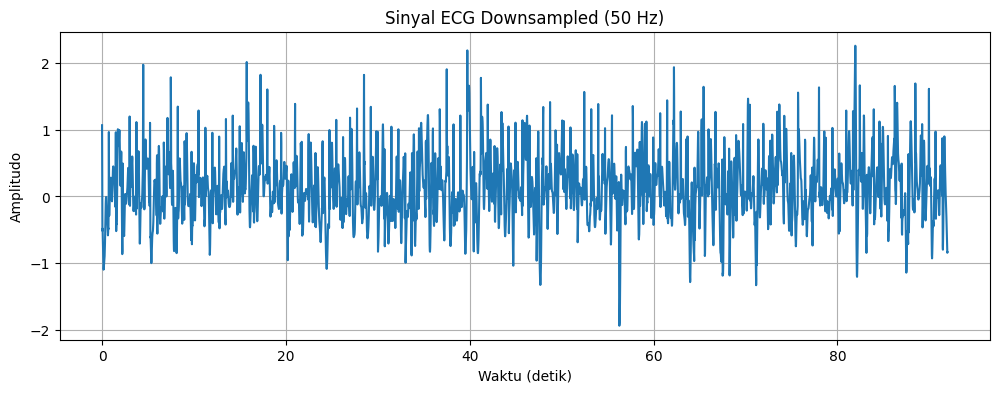

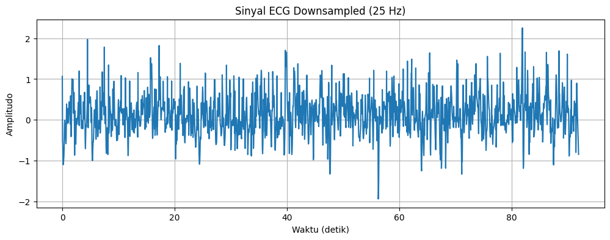

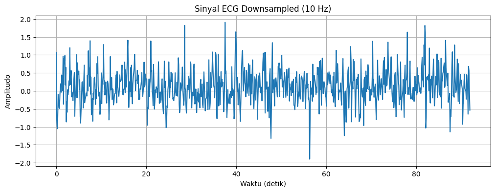

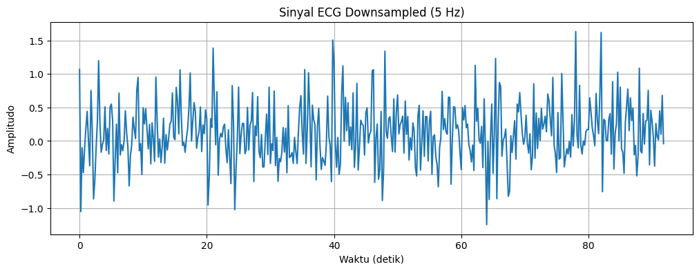

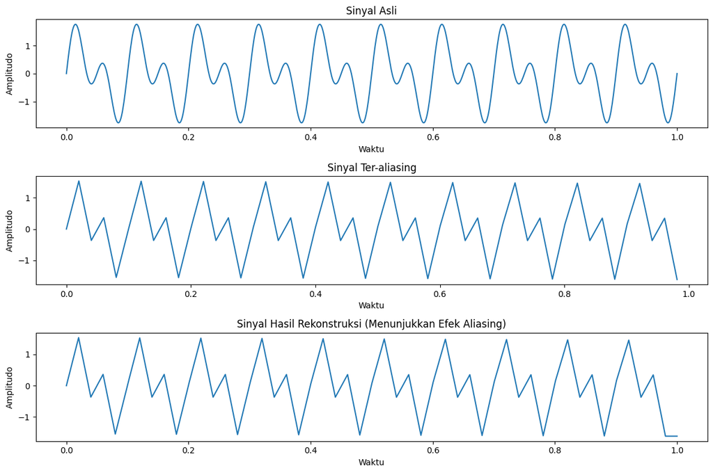

```python
import numpy as np
import matplotlib.pyplot as plt
import neurokit2 as nk

# Membuat sinyal ECG sintetis
sampling_rate = 150
ecg = nk.ecg_simulate(duration=92, sampling_rate=sampling_rate, noise=0.92, heart_rate=80, random_state=30819)

# Fungsi untuk melakukan downsampling
def downsample(signal, original_fs, target_fs):
    factor = original_fs // target_fs
    return signal[::factor]

# Fungsi untuk plot sinyal
def plot_signal(signal, fs, title):
    time = np.arange(len(signal)) / fs
    plt.figure(figsize=(12, 4))
    plt.plot(time, signal)
    plt.title(title)
    plt.xlabel('Waktu (detik)')
    plt.ylabel('Amplitudo')
    plt.grid(True)
    plt.show()

# Plot sinyal asli
plot_signal(ecg, sampling_rate, 'Sinyal ECG Asli (150 Hz)')

# Lakukan downsampling dan plot hasilnya
target_rates = [100, 50, 25, 10, 5]

for rate in target_rates:
    downsampled = downsample(ecg, sampling_rate, rate)
    plot_signal(downsampled, rate, f'Sinyal ECG Downsampled ({rate} Hz)')

# Demonstrasi aliasing
def demonstrate_aliasing():
    t = np.linspace(0, 1, 1000)
    original_signal = np.sin(2 * np.pi * 10 * t) + np.sin(2 * np.pi * 20 * t)

    plt.figure(figsize=(12, 8))

    plt.subplot(3, 1, 1)
    plt.plot(t, original_signal)
    plt.title('Sinyal Asli')
    plt.xlabel('Waktu')
    plt.ylabel('Amplitudo')

    # Downsampling yang menyebabkan aliasing
    aliased_signal = original_signal[::20]
    t_aliased = t[::20]

    plt.subplot(3, 1, 2)
    plt.plot(t_aliased, aliased_signal)
    plt.title('Sinyal Ter-aliasing')
    plt.xlabel('Waktu')
    plt.ylabel('Amplitudo')

    # Rekonstruksi sinyal (menunjukkan efek aliasing)
    reconstructed = np.interp(t, t_aliased, aliased_signal)

    plt.subplot(3, 1, 3)
    plt.plot(t, reconstructed)
    plt.title('Sinyal Hasil Rekonstruksi (Menunjukkan Efek Aliasing)')
    plt.xlabel('Waktu')
    plt.ylabel('Amplitudo')

    plt.tight_layout()
    plt.show()

demonstrate_aliasing()
```

Aliasing adalah suatu efek yang terjadi jika tidak memenuhi kriteria maka akan timbul frekuensi-frekuensi yang tidak diinginkan yang tidak terdapat pada sinyal asli sehingga sinyal asli tidak akan didapatkan kembali tanpa cacat. (Prasetiyo, Sofyan Mufti, et al. "Teknologi Komunikasi Digital Dan Analog: Konversi, Transmisi." Buletin Ilmiah Ilmu Komputer dan Multimedia (BIIKMA) 1.6 (2024): 750-762.)

Efek Penurunan Sampling Frequency:

### 6. Parameter order saat filtering

Parameter order pada pemrosesan sinyal yaitu tingkat kompleksitas atau tingkat kebebasan sebuah filter atau model. Semakin tinggi order suatu filter, semakin kompleks bentuk respon frekuensinya, yang artinya filter tersebut mampu melakukan operasi yang lebih rumit pada sinyal.

Dampak jika mengubah nilai order yaitu:

- Kompleksitas Perhitungan: Semakin tinggi order, semakin kompleks perhitungan yang diperlukan untuk mendesain dan mengimplementasikan filter atau model.
- Akurasi Model: Order yang terlalu rendah dapat menyebabkan underfitting, di mana model tidak mampu menangkap kompleksitas data. Sebaliknya, order yang terlalu tinggi dapat menyebabkan overfitting, di mana model terlalu menyesuaikan diri dengan noise dalam data.
- Biaya Komputasi: Filter dengan order tinggi umumnya membutuhkan lebih banyak sumber daya komputasi untuk diimplementasikan secara real-time.
- Respon Frekuensi: Order filter mempengaruhi bentuk respon frekuensi, seperti tingkat riak, ketajaman transisi, dan selektivitas frekuensi.

### 7. eksperimen dengan merancang filter band-pass menggunakan signal.butter

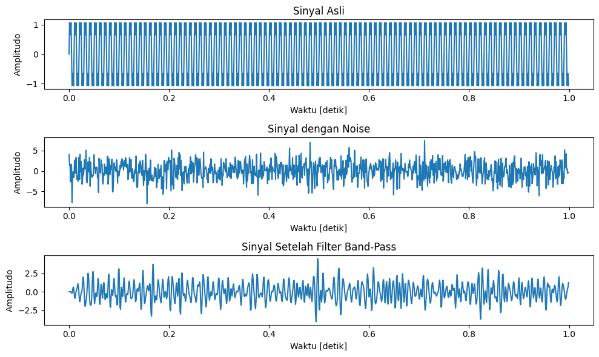

[figure not shown]

```python
import numpy as np
from scipy import signal
import matplotlib.pyplot as plt

fs = 1000  # Frekuensi sampling dalam Hz
lowcut = 80  # Frekuensi cut-off bawah dalam Hz
highcut = 200  # Frekuensi cut-off atas dalam Hz
order = 7

# Fungsi untuk membuat filter band-pass
def butter_bandpass(lowcut, highcut, fs, order):
    nyq = 0.5 * fs
    low = lowcut / nyq
    high = highcut / nyq
    b, a = signal.butter(order, [low, high], btype='band')
    return b, a

# Fungsi untuk menerapkan filter
def butter_bandpass_filter(data, lowcut, highcut, fs, order):
    b, a = butter_bandpass(lowcut, highcut, fs, order)
    y = signal.lfilter(b, a, data)
    return y

# Buat sinyal contoh
t = np.linspace(0, 1, fs, False)  # 1 detik
signal_clean = np.sin(2*np.pi*100*t) + 0.5*np.sin(2*np.pi*300*t)
signal_noisy = signal_clean + 2*np.random.randn(len(t))

# Terapkan filter
filtered_signal = butter_bandpass_filter(signal_noisy, lowcut, highcut, fs, order)

# Plot hasil
plt.figure(figsize=(10, 6))
plt.subplot(3, 1, 1)
plt.plot(t, signal_clean)
plt.title('Sinyal Asli')
plt.xlabel('Waktu [detik]')
plt.ylabel('Amplitudo')

plt.subplot(3, 1, 2)
plt.plot(t, signal_noisy)
plt.title('Sinyal dengan Noise')
plt.xlabel('Waktu [detik]')
plt.ylabel('Amplitudo')

plt.subplot(3, 1, 3)
plt.plot(t, filtered_signal)
plt.title('Sinyal Setelah Filter Band-Pass')
plt.xlabel('Waktu [detik]')
plt.ylabel('Amplitudo')

plt.tight_layout()
plt.show()

# Plot respons frekuensi filter
w, h = signal.freqs(*butter_bandpass(lowcut, highcut, fs, order))
plt.figure(figsize=(5, 3))
plt.semilogx(w, 20 * np.log10(abs(h)))
plt.title('Respons Frekuensi Filter Band-Pass Butterworth')
plt.xlabel('Frekuensi [Hz]')
plt.ylabel('Amplitudo [dB]')
plt.grid(True)
plt.axvline(lowcut, color='green')  # Frekuensi cut-off bawah
plt.axvline(highcut, color='green')  # Frekuensi cut-off atas
plt.show()
```

#### Apa yang terjadi jika lowcut menjadi 120 Hz dan highcut menjadi 210 Hz?

1. Pergeseran pita frekuensi:

Filter band-pass akan meloloskan frekuensi antara 120 Hz dan 210 Hz, bukan 80 Hz sampai 200 Hz seperti sebelumnya. Ini berarti rentang frekuensi yang diloloskan menjadi lebih sempit (90 Hz vs 120 Hz sebelumnya) dan bergeser ke frekuensi yang lebih tinggi.

2. Efek pada sinyal:

Sinyal dengan frekuensi 100 Hz (komponen utama dari sinyal bersih) akan diredam lebih kuat karena sekarang berada di bawah frekuensi cut-off bawah. Komponen sinyal dengan frekuensi 300 Hz akan tetap diredam karena masih di atas frekuensi cut-off atas.

3. Perubahan pada hasil filtering:

Sinyal hasil filtering akan memiliki amplitudo yang lebih kecil karena komponen 100 Hz yang dominan akan lebih teredam. Noise pada rentang 120-210 Hz akan lebih terlihat dalam sinyal hasil filtering.

4. Perubahan pada respons frekuensi:

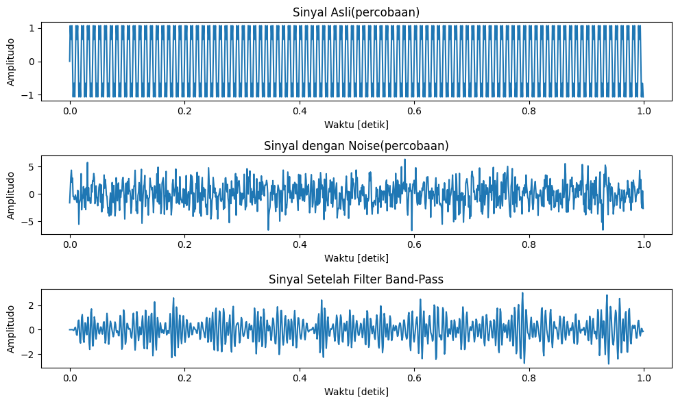

[figure not shown]

```python
import numpy as np
from scipy import signal
import matplotlib.pyplot as plt

fs = 1000  # Frekuensi sampling dalam Hz
lowcut = 120  # Frekuensi cut-off bawah dalam Hz
highcut = 210  # Frekuensi cut-off atas dalam Hz
order = 7

# Fungsi untuk membuat filter band-pass
def butter_bandpass(lowcut, highcut, fs, order):
    nyq = 0.5 * fs
    low = lowcut / nyq
    high = highcut / nyq
    b, a = signal.butter(order, [low, high], btype='band')
    return b, a

# Fungsi untuk menerapkan filter
def butter_bandpass_filter(data, lowcut, highcut, fs, order):
    b, a = butter_bandpass(lowcut, highcut, fs, order)
    y = signal.lfilter(b, a, data)
    return y

# Buat sinyal contoh
t = np.linspace(0, 1, fs, False)  # 1 detik
signal_clean = np.sin(2*np.pi*100*t) + 0.5*np.sin(2*np.pi*300*t)
signal_noisy = signal_clean + 2*np.random.randn(len(t))

# Terapkan filter
filtered_signal = butter_bandpass_filter(signal_noisy, lowcut, highcut, fs, order)

# Plot hasil
plt.figure(figsize=(10, 6))
plt.subplot(3, 1, 1)
plt.plot(t, signal_clean)
plt.title('Sinyal Asli(percobaan)')
plt.xlabel('Waktu [detik]')
plt.ylabel('Amplitudo')

plt.subplot(3, 1, 2)
plt.plot(t, signal_noisy)
plt.title('Sinyal dengan Noise(percobaan)')
plt.xlabel('Waktu [detik]')
plt.ylabel('Amplitudo')

plt.subplot(3, 1, 3)
plt.plot(t, filtered_signal)
plt.title('Sinyal Setelah Filter Band-Pass')
plt.xlabel('Waktu [detik]')
plt.ylabel('Amplitudo')

plt.tight_layout()
plt.show()

# Plot respons frekuensi filter
w, h = signal.freqs(*butter_bandpass(lowcut, highcut, fs, order))
plt.figure(figsize=(5, 3))
plt.semilogx(w, 20 * np.log10(abs(h)))
plt.title('Respons Frekuensi Filter Band-Pass Butterworth')
plt.xlabel('Frekuensi [Hz]')
plt.ylabel('Amplitudo [dB]')
plt.grid(True)
plt.axvline(lowcut, color='green')  # Frekuensi cut-off bawah
plt.axvline(highcut, color='green')  # Frekuensi cut-off atas
plt.show()
```

### Referensi

saya menggunakan referensi bantuan AI (LLM) menggunakan claude.ai dan chatgpt

[figure not shown]